# Задание 2

Assigned: October 17, 2019

##### Для выполнения задания следуйте следующему:

1. Замените “Введите имя” в поле `author:` на свое ФИО.
2. Выполняйте задание путем редактирования файла `homework2.Rmd`.
3. После выполнения работы, убедитесь, что ваш код выполняется как в консоле, так и путем запуска knit HTML, поменяйте название сохраненного файла на `homework1_Вашеимя.Rmd` (Вашеимя поменяйте на ФИО) и отправьте на почту ""

##### Homework tips:

1. Вместо построчного запуска путем нажатия `<ctrl-enter>` можно запускать целые блоки кода. Посмотрите опции в меню
2. Проверяйте код в консоле, запускайте Knit HTML по мере выполнения для проверки на ошибки.

### Задание 1: Функции

##### (a) Создание функции.

Дана переменная $x$, создайте альтернативу функции `mean` для вычисления среднего по генеральной совокупности. Назовите функцию `avg`

```r
# Функция avg
avg1 <- function(x, trim = 0, na.rm = F){
  if (trim > 0) {
    len <- length(x)
    endPoint <- floor(len*trim)
    stP <- 1+endPoint
    enP <- len-endPoint
    naSum <- sum(is.na(x))
    x <- sort(x, na.last= F)[naSum:len]
    x <- x[stP:enP]
    # так и не понял до конца алгоритм реализации trim в mean, т.к. все равно есть расхождение
  }
  sum(x,na.rm = na.rm)/(length(x)-sum(is.na(x)))
}
trim <- 0.2
naRm <- T
x <- c(1:50,NA,1,2,3,4,NA,7,1,10)

list(avg = avg1(x, na.rm = naRm),
     mean = mean(x, na.rm = naRm),
     avg_trimmed = avg1(x, trim = trim, na.rm = naRm),
     mean_trimmed = mean(x, trim = trim, na.rm = naRm))
```

[output not shown]

##### (b) Модификация функции.

Модифицируйте созданную функцию `avg` дополнительным *логическим* параметром $a$, который будет указан в input этой функции `avg(x,a)`. Если $a$ принимает значение `TRUE`, то происходит вычисление арифметического среднего, иначе - геометрического среднего.

```r
# Введите код модифицированной avg
avg2 <- function(x, a = F, trim = 0, na.rm = F) {
  if (trim > 0) {
    len <- length(x)
    endPoint <- floor(len*trim)
    stP <- 1+endPoint
    enP <- len-endPoint
    naSum <- sum(is.na(x))
    x <- sort(x, na.last= F)[naSum:len]
    x <- x[stP:enP]
    # так и не понял до конца алгоритм реализации trim в mean, т.к. все равно есть расхождение
  }
  if (a == T) {
    return(sum(x,na.rm = na.rm)/(length(x)-sum(is.na(x))))
  }
  prod(x, na.rm = na.rm)**(1/(length(x)-sum(is.na(x))))
}
x <- c(1,2,3,4,NA,7,1,10)

list(avg_a = avg2(x, a = T, na.rm = T),
     avg_g = avg2(x, a = F, na.rm = T))
```

```
## $avg_a
## [1] 4
##
## $avg_g
## [1] 2.889073
```

##### (c) Использование цикла for.

Создайте функцию, вычисляющую сумму ряда от 1 до $n$ и записывающую результат в предварительно созданный вектор

```r
# m - input
sumRange1 <- function(s) {
  for(i in 1:length(s)) {
    s[i] <- sum(1:i)
  }
  return(s)
}

#m <- as.numeric(readline(prompt = "Enter range length: "))
m <- 10
s <- vector(length=m)
s <- sumRange1(s)
s
```

[output not shown]

##### (d) Использование результатов функции.

Выведите график, по оси абсцисс значения $n = 1:m$, по оси ординат - значения вектора из задания **(c)**.

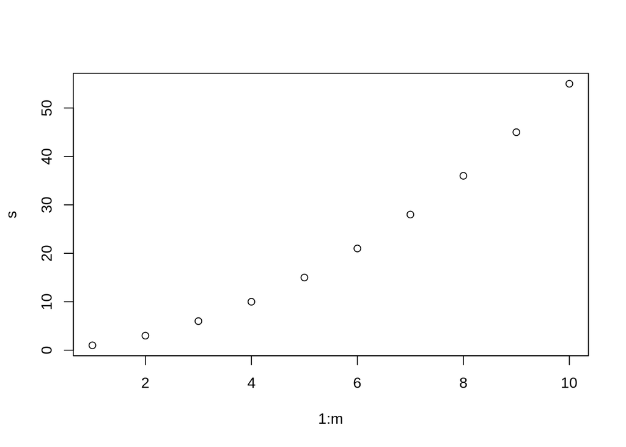

```r
# График, функция суммы вызывается внутри функции построения графика
sumRange1 <- function(s) {
  for(i in 1:length(s)) {
    s[i] <- sum(1:i)
  }
  return(s)
}

m <- 10
s <- vector(length=m)
s <- sumRange1(s)
plot(1:m, s)
```

##### (e) Еще на создание фуДнкции.

Создайте функцию “altman”. Эта функция на вход принимает два аргумента $x$ и $y$ и строит график разности их сумм.

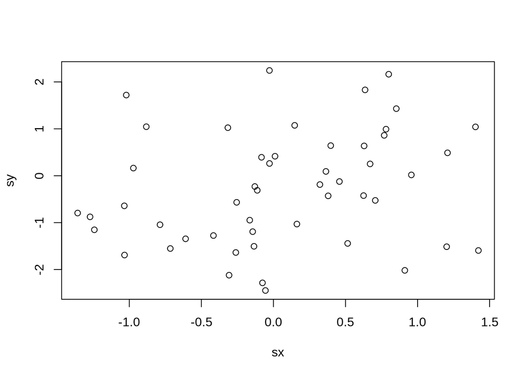

```r
altman <- function(x,y) {
  if(length(x) != length(y)) {
    print("x and y must have the same length")
    return(F)
  }
  sx <- (x + y)/2
  sy <- x - y
  par(mfrow=c(1,1))
  plot(sx, sy)
}
x <- rnorm(50)
y <- rnorm(50)
altman(x = x, y = y)
```

##### (f) sapply.

Повторите задание **(c)** используя `sapply`

```r
sumRange2 <- function(s) {
  s <- 1:length(s)
  for (i in 2:length(s)) {
    s[i] <- sapply(s[(i-1)], sum, i)
  }
  return(s)
}

#m <- as.numeric(readline(prompt = "Enter range length: "))
m <- 10
s <- vector(length=m)
s <- sumRange2(s)
s
```

[output not shown]

##### (g) Подтверждение формулы.

Подтвердите формулу. Для этого создайте функцию, вычисляющую сумму ряда по формуле ${{S}_{n}}=1+2+...+n$ и постройте ее график, затем нанесите на график линию c помощью команды `lines`.

```r
# постройте график
sumRange3 <- function(n) {
  for(i in 1:length(s)) {
    s[i] <- sum(1:i)
  }
  return(s)
}

n <- 10
s_n <- sumRange3(n)
par(mfrow=c(1,1))
plot(1:n, s_n)
lines(1:n,s_n) # нанесение на график линии
#lines(n, n*(n+1)/2)
```

[output not shown]

##### (h) Подтверждение формулы.

В этот раз вычисляется сумма ${{S}_{n}}={{1}^{2}}+{{2}^{2}}+...+{{n}^{2}}$. Создайте функцию для ее вычисления, постройте график и нанесите на график линию c помощью команды `lines`.

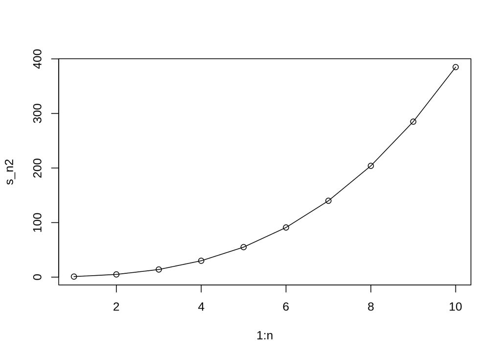

```r
sumRange2 <- function(n) {
  v <- 1^2
  for(i in 2:n) {
    v[i] <- sapply(v[(i-1)], sum, i^2)
  }
  return(v)
}

n <- 10
s_n2 <- sumRange2(n)
plot(1:n, s_n2)
lines(1:n, s_n2)
```

```r
#lines(n, n*(n+1)(2*n+1)/6)
```

### Задание 2: Выборка

Загрузите выборку `income` из ednet.bulgakov.app по ссылке “https://ednet.bulgakov.app/storage/documents/6900/GJhOvscxctbJhIKgazwiPSbvoCcmiYss8NzLJDV9.txt” В данной выборке содержатся данные об опросах

```r
# дополните код
setwd("~/devel/courses/r-basics/code/hw02")
income <- read.csv("income.csv")
income$X <- NULL

# задайте имена переменным
colnames(income) <- c("age", "workclass", "fnlwgt", "education", "education.years", "marital.status", "occupation", "relationship", "race", "sex", "capital.gain", "capital.loss", "hours.per.week", "native.country", "income.bracket")
```

##### (a) table(), tapply()

Используя функцияю `table()` для вывода таблицы сопряженности по наблюдениям через **marital status** и* **sex**

```r
income <- read.csv("income.csv")
income$X <- NULL
colnames(income) <- c("age", "workclass", "fnlwgt", "education", "education.years", "marital.status", "occupation", "relationship", "race", "sex", "capital.gain", "capital.loss", "hours.per.week", "native.country", "income.bracket")
table(income$marital.status, income$sex)
```

```
##
##                         Female  Male
##   Divorced                2672  1771
##   Married-AF-spouse         14     9
##   Married-civ-spouse      1657 13319
##   Married-spouse-absent    205   213
##   Never-married           4767  5916
##   Separated                631   394
##   Widowed                  825   168
```

##### (b) prop.table()

Функция `prop.table()` вычисляет таблицу пропорций. Почитайте документацию по этой функции, чтобы понять, как она работает. Используйте ее к заданию **(a)**. Столбец `Female` должен показывать пропорцию женщин с каждой категорией семейного статуса, столбец `Male` - ту же информацию для мужчин.

```r
# Отредактируйте
prop.table(table(income$marital.status, income$sex), 2)
```

```
##
##                               Female         Male
##   Divorced              0.2480735308 0.0812758146
##   Married-AF-spouse     0.0012997865 0.0004130335
##   Married-civ-spouse    0.1538390122 0.6112436898
##   Married-spouse-absent 0.0190325875 0.0097751262
##   Never-married         0.4425772909 0.2715006884
##   Separated             0.0585832328 0.0180816888
##   Widowed               0.0765945595 0.0077099587
```

##### (с) Используйте задание (b) для ответа на следующие вопросы. Согласно выборки, имеют ли женщины большую вероятность, чем мужчины быть `Married`? Большую вероятность быть `Widowed`? (Для ответа вычислите процент индивидов по каждой группе). Используйте блоки inline code для ответа на вопросы.

Согласно выборки, женщины могут быть `Married` с вероятностью 17.42%, в то время, как мужчины могут быть `Married` с вероятностью 62.14%.

При этом доля женщин со статусом `Widowed` составляет 7.66% от общего числа женщин. Доля же мужчин со статусом `Widowed` составляет только 0.77% от общего числа.

##### (d) tapply()

Используйте `tapply()` для вывода таблицы, показывающей среднее значение **education** (в годах) по категориям **marital status** и **sex**.

```r
tapply(income$education.years, list(income$marital.status, income$sex), mean)
```

```
##                          Female      Male
## Divorced              10.070359  9.970073
## Married-AF-spouse     10.142857 10.222222
## Married-civ-spouse    10.378998 10.313387
## Married-spouse-absent  9.751220  8.882629
## Never-married         10.181246  9.786173
## Separated              9.212361  9.423858
## Widowed                9.092121  9.101190
```

### Задание 3: Более сложный пример на `tapply()`

В пакете `MASS` содержится выборка, называемая Insurance. Прочитайте help, чтобы понять ее содержимое.

#####(a) Число полисодержателей по району и возрасту

Используйте `tapply()` для вывода таблицы, показывающей общее число полисодержателей по району и возрасту. Сохраните эту таблицу в переменную, а также выведите ее на экран.

```r
library(MASS)
insH <- tapply(Insurance$Holders, INDEX = Insurance[c("District", "Age")], sum)
insH
```

```
##         Age
## District <25 25-29 30-35  >35
##        1 638  1157  1396 7354
##        2 309   675   863 4806
##        3 119   335   493 3220
##        4  72   169   255 1498
```

#####(b) Число претензий по району и возрасту

Используйте `tapply()` для вывода таблицы, показывающей общее число претензий (Claims). Сохраните данную таблицу в переменную, а также выведите ее на экран.

```r
# Неизвестно по какому фактору
insC <- tapply(Insurance$Claims, INDEX = Insurance[c("District", "Age")], sum)
insC
```

```
##         Age
## District <25 25-29 30-35 >35
##        1 124   189   202 866
##        2  65   131   122 573
##        3  26    56    79 392
##        4  14    28    50 234
```

#####(c) Уровень претензий на полисодержателя по району и возрасту

Используйте ответы из заданий **(a)** и **(b)** для вывода таблицы, показывающей уролвень претензий на полисодержателя по району и возрасту

```r
aCH <- apply(insC/insH, 2, mean); for(i in 2:length(aCH)) {z <- aCH[i]-aCH[i-1]}; round(abs(mean(z)), 3)*100
```

```
## [1] 3.2
```

Tip: *Если страховая компания имеет 120 тыс. полисодержателей и получает 14 тыс претензий, то уровень равен 14000/120000 = 0.117*

#####(d) Какие тренды можно увидеть в том, как число претензий на полисодержателя варьируется по возрасту?

### Задание 4: Применение функций

##### (a) Создайте функцию ограниченного среднего

На вход поступает числовой вектор `x`, игнорируется `s` маленьких и `l` больших значений.

Т.е., если `x = c(1, 7, 3, 2, 5, 0.5, 9, 10)`, `s = 1`, и `l = 2`, функция должна вернуть среднее `c(1, 7, 3, 2, 5)` (вектор `x` без учета 1 наименьшего значения (0.5) и 2 наибольших значений (9, 10) ).

Ваша функция должна использовать функцию `length()` для проверки, что `x` имеет по крайней мере `s + l + 1` значений. Если `x` короче `s + l + 1`, то функция должна выводить `message()` для пользователя о невозможности посчитать ограниченное среднее. Если `x` имеет длину от `s + l + 1`, то функция выводит результат.

```r
# Скелет функции

# Заполните и добавьте для меня комментарии
trimmedMean <- function(x, s = 0, l = 0) {
  # Выдаем ошибку, если длина вектора не только меньше суммы s и l,
  # но и если равна ей (пустой диапазон).
  if(length(x) <= sum(s,l)) {
    message("Sorry, can't calculate trimmed mean. Try another values.")
  }
  # Для удаления наименьших и наибольших значений
  # (1) сортируем вектор,
  # (2) берем его срез, начиная с индекса 1+s, и заканчивая индексом length(x)-l,
  # (3) вычисляем среднее по срезу.
  mean(sort(x)[(1+s):(length(x)-l)])
}
x <- c(1, 7, 3, 2, 5, 0.5, 9, 10)
trimmedMean(x,s=1,l=2)
```

```
## [1] 3.6
```

**Note:** Обратите внимание, что `s = 0` и `l = 0` специфицированы в input функции. Если пользователь не указывает их в запросе, то рассчитывается обычное среднее.

##### (b) Применение функции с циклом for

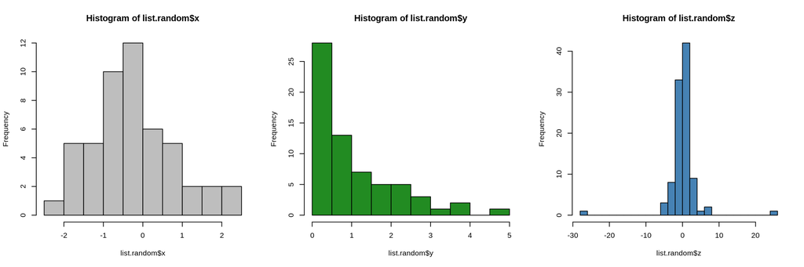

```r
set.seed(201802) # зерно датчика случайных чисел
list.random <- list(x = rnorm(50),
                    y = rexp(65),
                    z = rt(100, df = 1.5))

# Гистограммы данных
par(mfrow = c(1,3))
hist(list.random$x, breaks = 15, col = 'grey')
hist(list.random$y, breaks = 10, col = 'forestgreen')
hist(list.random$z, breaks = 20, col = 'steelblue')
```

Используя цикл `for` и функцию из задания **(a)**, создайте вектор, элементы которого будут ограниченными средними векторов в `list.random`, взяв за `s = 5` и `l = 5`.

```r
count <- 1
resMT <- c()
for(i in 1:length(names(list.random))) {
  resMT[count] <- trimmedMean(list.random[[i]],s=5,l=5)
  count <- count + 1
}
resMT
```

```
## [1] -0.25898051  0.88285719  0.09086078
```

##### (c) Вычислите неограниченные средние для векторов из списка. Как можно их сравнить с ограниченными средними из задания (b)? Объясните полученный результат.

```r
count <- 1
resM <- c()
for(i in 1:length(names(list.random))) {
  resM[count] <- mean(list.random[[i]])
  count <- count + 1
}
resM
```

```
## [1] -0.22171186  1.03795962  0.06563583
```

**Объяснение:**

Сравнить усеченное среднее и неусеченное среднее можно относительно медианы числового ряда. При увеличении степени усечения показатель средней стремится к медиане. Это происходит по той причине, что характеристика с усечением становится менее чувствительна к выбросам.

##### (d) lapply(), sapply()

Повторите часть **(b)**, используя `lapply` и `sapply` функции вместо цикла for. Команда `lapply` должна возвращать список ограниченных средних, а `sapply` должна возвращать вектор ограниченных средних

```r
lapply(list.random, FUN = trimmedMean, s = 5, l = 5)
```

```
## $x
## [1] -0.2589805
##
## $y
## [1] 0.8828572
##
## $z
## [1] 0.09086078
```

```r
sapply(list.random, FUN = trimmedMean, s = 5, l = 5)
```

```
##           x           y           z
## -0.25898051  0.88285719  0.09086078
```

**Hint** `lapply` и `sapply` могут брать аргументы для передачи в функцию `trimmedMean` Т.е., если будете применять функцию `sort`, в которой есть аргумент `decreasing`, можно использовать следующий синтакиси `lapply(..., FUN = sort, decreasing = TRUE)`.

### Задание лекции 5: Создать функцию расчета квантиля. Quant(x,0.25) должна выдать значение первого квартиля. Вывод такой же как в стандартной функции quantile().

```r
Quant <- function(x,q) {
# type 7
  x <- sort(x)
  h <- (length(x)-1)*q+1
  if(is.integer(h)) {
    return(x(h))
  }
  return(x[floor(h)]+(h-floor(h))*(x[floor(h)+1]-x[floor(h)]))
}

x <- rnorm(10)
quantile(x)
```

```
##         0%        25%        50%        75%       100%
## -1.4107096 -0.8437480 -0.3554316  0.1157181  0.2694552
```

```r
Quant(x,0.25)
```

```
## [1] -0.843748
```